# DRL - Snake Analytics

Here I load the training results for three agents: A2C efficiency, PPO efficiency, and PPO maximizer. I’ll compare them across different metrics

```python
from pathlib import Path
import numpy as np
import pandas as pd
import matplotlib.pyplot as plt

plt.rcParams["figure.figsize"] = (10, 6)
plt.rcParams["axes.grid"] = True

# Resolve project root & logs irrespective of where the notebook lives
HERE = Path.cwd()
if (HERE / "logs").exists():
    PROJECT_ROOT = HERE
elif (HERE.parent / "logs").exists():
    PROJECT_ROOT = HERE.parent
else:
    PROJECT_ROOT = HERE

LOGS = PROJECT_ROOT / "logs"
```

### Setup and Data Loading

In this section we import libraries, set up paths, and load the CSV logs for each Snake model:

- **A2C_Efficiency**
- **PPO_Efficiency**
- **PPO_Maximizer**

These CSVs contain training metrics like episode score, episode length, and death type. These metrics are gathered and saved during the initial training.  
We also define a helper function for calculating a rolling mean, which smooths noisy results to better show long-term learning trends.

```python
paths = {
    "A2C_Efficiency": LOGS / "training_metrics_snake_a2c_efficiency.csv",
    "PPO_Efficiency": LOGS / "training_metrics_snake_ppo_efficiency.csv",
    "PPO_Maximizer":  LOGS / "training_metrics_snake_ppo_maximizer.csv",
}

dfs = {}
for name, p in paths.items():
    if not p.exists():
        raise FileNotFoundError(f"Missing: {p}")
    df = pd.read_csv(p)
    df.columns = [c.lower() for c in df.columns]
    # keep only the basics + death_type if available
    keep = [c for c in ["episode","timestep","score","episode_length","death_type"] if c in df.columns]
    df = df[keep].sort_values("episode").reset_index(drop=True)
    # ensure numeric
    for col in ["episode","timestep","score","episode_length"]:
        if col in df.columns:
            df[col] = pd.to_numeric(df[col], errors="coerce")
    dfs[name] = df.dropna(subset=["episode","timestep","score","episode_length"])

def rolling_mean(s, window=20):
    return s.rolling(window, min_periods=max(5, window//4)).mean()
```

### Learning Curve: Score

This plot shows the rolling average score across training timesteps.  
It demonstrates how each agent improves over time. PPO typically converges faster and to a higher score, while A2C improves at a slower rate.  
The **efficiency persona** tends to score higher because it prioritizes steady growth, while the **maximizer persona** is more aggressive and only prioritizes eating apples.

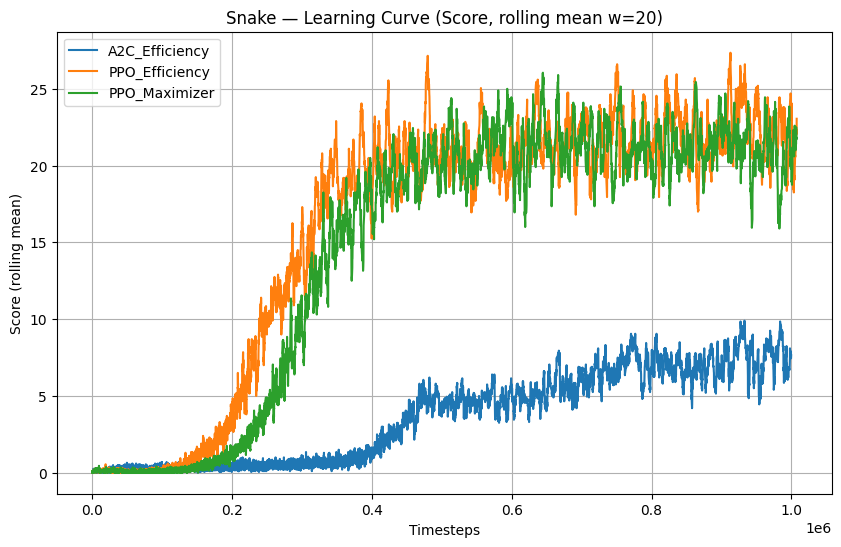

```python
plt.figure()
for name, df in dfs.items():
    y = rolling_mean(df["score"], 20)
    plt.plot(df["timestep"], y, label=name)
plt.title("Snake — Learning Curve (Score, rolling mean w=20)")
plt.xlabel("Timesteps")
plt.ylabel("Score (rolling mean)")
plt.legend()
plt.show()
```

### Learning Curve: Episode Length

This plot shows how long the agents survive during training.  
Longer episode lengths indicate better survival.  
Again, the PPO models have similar results, with PPO_Efficiency tending to have longer episodes than PPO_Maximizer. The interesting thing is how the A2C has a massive range of episode lengths. This means that A2C does have episodes just as long as the PPO models but A2C achieves a much lower score during those episodes.

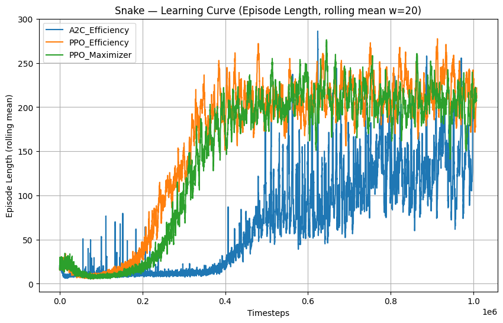

```python
plt.figure()
for name, df in dfs.items():
    y = rolling_mean(df["episode_length"], 20)
    plt.plot(df["timestep"], y, label=name)
plt.title("Snake — Learning Curve (Episode Length, rolling mean w=20)")
plt.xlabel("Timesteps")
plt.ylabel("Episode Length (rolling mean)")
plt.legend()
plt.show()
```

### Rolling Crash Rates: Wall vs Self

This analysis looks at the cause of agent deaths over time.  
We track whether the snake crashes into the **wall** or into **itself**.  
Patterns reveal differences in play style:

- Efficiency persona may drift toward wall crashes by staying alive longer but getting cornered.
- Maximizer persona may crash into itself more often as it aggressively grows.

The take away from these graphs are A2C never really learns to avoid the walls, this could be why it has the worst performance. When looking at PPO Efficiency vs Maximizer we can see that PPO_Efficiency learns to avoid the walls a bit sooner when compared to PPO_Maximizer.

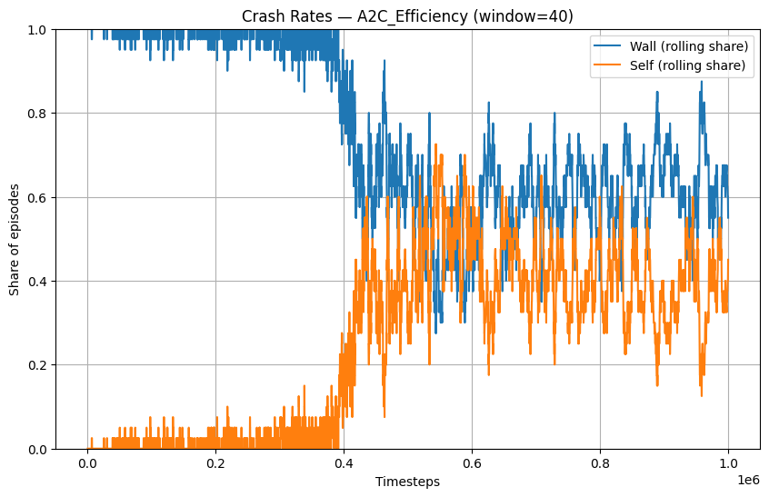

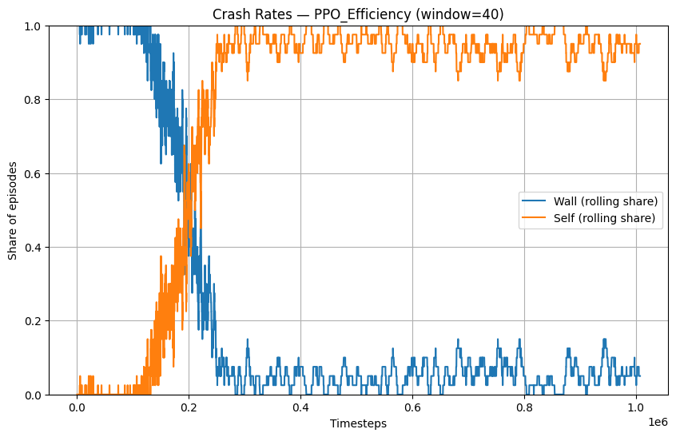

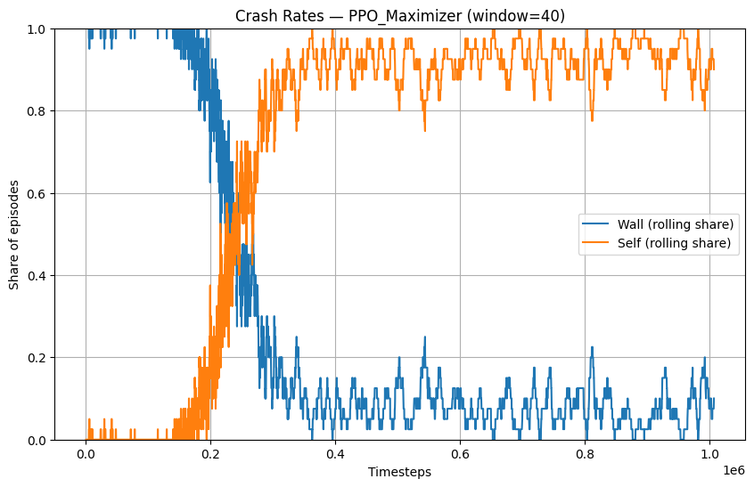

```python
window = 40

for name, df in dfs.items():
    if "death_type" not in df.columns or df["death_type"].isna().all():
        print(f"[{name}] No 'death_type' info — skipping crash-rate plot.")
        continue

    # Rolling proportion of episodes ending by 'wall' or 'self'
    is_wall = (df["death_type"] == "wall").astype(float)
    is_self = (df["death_type"] == "self").astype(float)

    wall_share = is_wall.rolling(window, min_periods=5).mean()
    self_share = is_self.rolling(window, min_periods=5).mean()

    plt.figure()
    plt.plot(df["timestep"], wall_share, label="Wall (rolling share)")
    plt.plot(df["timestep"], self_share, label="Self (rolling share)")
    plt.ylim(0, 1)
    plt.xlabel("Timesteps")
    plt.ylabel("Share of episodes")
    plt.title(f"Crash Rates — {name} (window={window})")
    plt.legend()
    plt.show()
```

### More Data Loading

Here we are loading more CSV logs for each Snake model:

- **A2C_Efficiency**
- **PPO_Efficiency**
- **PPO_Maximizer**

These CSVs contain training metrics like episode score, episode length, and death type. We get this data by evaluating our trained model.

```python
eval_paths = {
    "A2C_Efficiency": LOGS / "eval_snake_a2c_efficiency.csv",
    "PPO_Efficiency": LOGS / "eval_snake_ppo_efficiency.csv",
    "PPO_Maximizer":  LOGS / "eval_snake_ppo_maximizer.csv",
}

eval_dfs = {}
for name, p in eval_paths.items():
    if not p.exists():
        print(f"Missing eval file: {p}")
        continue
    df = pd.read_csv(p)
    df.columns = [c.lower() for c in df.columns]
    eval_dfs[name] = df
```

### Score Distribution

We can see that PPO_Efficiency has the highest score and highest median score. Looking back at the crash rates we saw that PPO_Efficiency learned to avoid the wall the quickest giving it more time steps to learn avoiding itself.

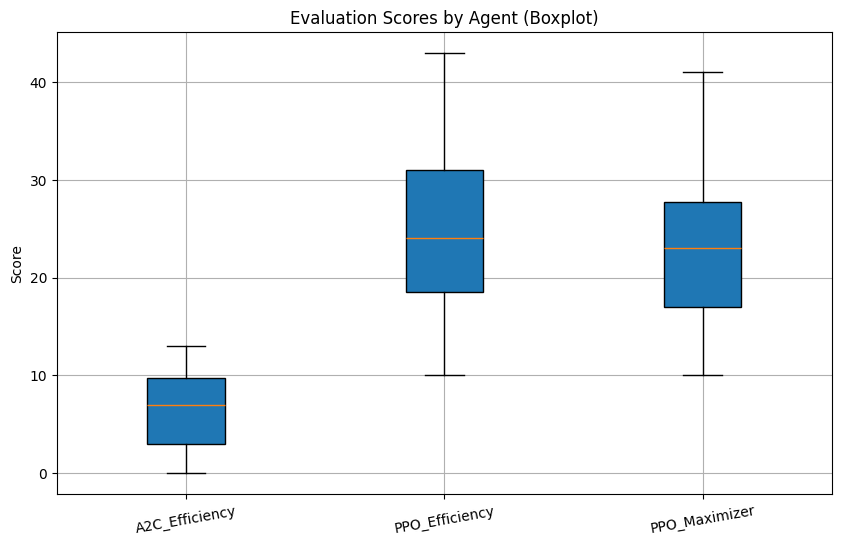

```python
plt.figure()
data = [df["score"] for df in eval_dfs.values()]
plt.boxplot(data, tick_labels=list(eval_dfs.keys()), vert=True, patch_artist=True)
plt.title("Evaluation Scores by Agent (Boxplot)")
plt.ylabel("Score")
plt.xticks(rotation=10)
plt.show()
```

### Summary Table

This table compares key metrics side by side:

The table makes it easy to directly compare algorithms and personas on multiple performance dimensions. From this we can see that both PPO models are close while the A2C model is quiet far behind.

```python
eval_summary = []
for name, df in eval_dfs.items():
    eval_summary.append({
        "Agent": name,
        "Episodes": len(df),
        "Mean Score (Eval)": df["score"].mean(),
        "Median Score (Eval)": df["score"].median(),
        "Mean Steps (Eval)": df["steps"].mean(),
        "Wall Deaths": (df.get("death_type") == "wall").sum(),
        "Self Deaths": (df.get("death_type") == "self").sum(),
    })
pd.DataFrame(eval_summary).round(2)
```

|  | Agent | Episodes | Mean Score (Eval) | Median Score (Eval) | Mean Steps (Eval) | Wall Deaths | Self Deaths |
| --- | --- | --- | --- | --- | --- | --- | --- |
| 0 | A2C_Efficiency | 50 | 6.30 | 7.0 | 397.08 | 22 | 11 |
| 1 | PPO_Efficiency | 50 | 24.84 | 24.0 | 242.04 | 1 | 49 |
| 2 | PPO_Maximizer | 50 | 22.84 | 23.0 | 219.14 | 1 | 49 |